# Exporting editable ggplot graphics to Power Point with officer and purrr

What, why, how, when, and who

Shannon Pileggi  
09-10-2020

# TL; DR

The [`officer`](https://davidgohel.github.io/officer/) and [`rvg`](https://github.com/davidgohel/rvg) packages can be used to create Power Point slides with editable ggplot graphics. Skip to creating a single Power Point slide or to efficiently exporting multiple Power Point graphics with `purrr`.

# What is an editable Power Point graphic?

An editable Power Point graphic that is created within Power Point consists of two sets of editable components:

1. Various features of the graphic are editable, including items like size, color, and font (see Gif 1).
2. The data behind the graphic are editable (see Gif 2). This means that you can open the table linked to the chart and manually edit it in order to alter the data displayed in the graphic.

An editable Power Point graphic constructed in R through the `officer` + `rvg` functions described here produce vector graphics (i.e., shapes). This permits editing various features of the graphic (e.g., color, size), but not the data behind it (no linked table is created).

# Why should I create it?

In my line of work, the primary deliverable is a Power Point slide deck. When creating an R graphic for a slide deck, I could export the graphic as an image (like a `.png`) to be inserted into Power Point, or I can export the graphic directly to an editable Power Point slide. Both of these options have pros and cons.

| Feature | Power Point editable graphic | Image (e.g., `.png`) |
| --- | --- | --- |
| Editability | 👍 | 👎 |
| Resizing | 👎 | 👍 |
| Data table | 👎 | 👎 |

The editable Power Point graphic allows for direct editing in Power Point, but re-sizes poorly when done manually within Power Point. A `.png` image does not allow for direct editing within Power Point, but does nicely retain image ratios when re-sizing. Lastly, neither method produces a linked data table behind the graphic for editing.

# How do I create it?

```r
library(tidyverse)
library(here)
library(glue)
library(officer)
library(rvg)
library(viridis)
```

First, let’s create a quick graphic for demonstration purposes using `ggplot2::diamonds`. We subset the data on specific values of `color` and `clarity` and produce a scatter plot showing the relationship between `price` and `carat`.

```r
p <- diamonds %>%
  filter(color == "D" & clarity == "I1") %>%
  ggplot(aes(x = carat, y = price, color = cut)) +
    geom_point() +
    theme_minimal() +
    ggtitle("Color: D; Clarity: I1")
```

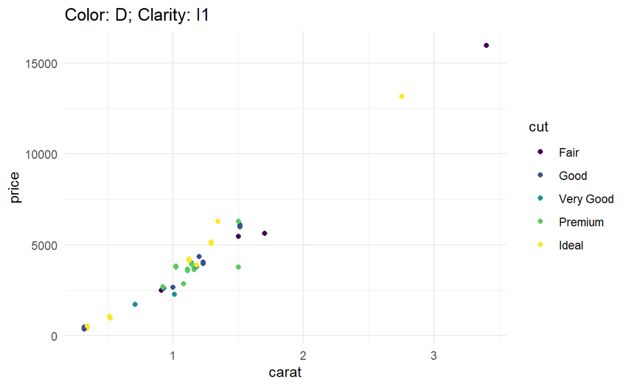

```r
p
```

In order to export this graphic to an editable Power Point slide, first use the [`rvg`](https://github.com/davidgohel/rvg) package to convert the object to class `dml` (required to make graphic editable).

```r
p_dml <- rvg::dml(ggobj = p)
```

Then export the `dml` object to a Power Point slide with [`officer`](https://davidgohel.github.io/officer/).

```r
# initialize Power Point slide ----
officer::read_pptx() %>%
  # add slide ----
  officer::add_slide() %>%
  # specify object and location of object ----
  officer::ph_with(p_dml, ph_location()) %>%
  # export slide -----
  base::print(target = here::here("_posts", "2020-09-10-draft-ppt", "slides", "demo_one.pptx"))
```

Here is a screen shot of the resulting Power Point slide, or you can download demo_one.pptx.

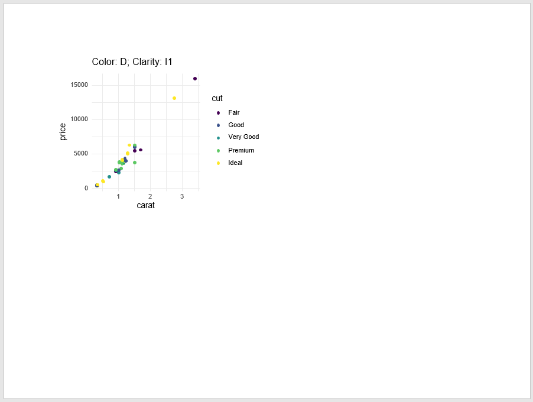

# When should I do this more efficiently?

There are 56 combinations of `color` and `clarity` in the `diamonds` data set; naturally, your colleague wants all 56 plots (at least for the appendix of the report 😂). So we definitely want an efficient way to do this!

### Automate many plots

This work follows up on blog posts by [Laurens Geffert](https://janlauge.github.io/2018/creating-editable-PowerPoint-plots-from-R/), [Len Kiefer](http://lenkiefer.com/2017/10/21/purrrtier-powerpoint-with-r/), and [Bruno Rodrigues](https://www.brodrigues.co/blog/2018-10-05-ggplot2_purrr_officer/), which were fantastic resources to help me get started. The `officer` package enacted changes in version 0.3.11(?) which necessitate updates to these methods (see Acknowledgements). In addition, [Amber Thomas](https://amber.rbind.io/2018/03/26/purrr/) demonstrated a `purrr::map2` work flow that resonates with me.

I start with a table outlining the 56 combinations of `color` and `clarity`.

```r
# tibble of all possible combinations ----
diamonds_grid <- diamonds %>%
  count(color, clarity) %>%
  # for mapping, we need input values to be character ----
  mutate_all(as.character)
```

```r
# view values of grid ----
diamonds_grid
```

```
# A tibble: 56 x 3
   color clarity n
   <chr> <chr>   <chr>
 1 D     I1      42
 2 D     SI2     1370
 3 D     SI1     2083
 4 D     VS2     1697
 5 D     VS1     705
 6 D     VVS2    553
 7 D     VVS1    252
 8 D     IF      73
 9 E     I1      102
10 E     SI2     1713
# ... with 46 more rows
```

Then I create a function that produces the plot for any given combination of `color` and `clarity`. As `ggplot` produces plots for the available data, there are some additional updates to this function to maintain consistency across all plots. We use a named color vector to create consistency in plotting colors across all plots, in addition to enforcing consistency in the `x` and `y` plotting ranges.

```r
# named vector for the colors assigned to cut ----
# values are the colors assigned ----
color_cut <- viridis::viridis(5) %>%
  # assign levels of cut as names to colors ----
  rlang::set_names(levels(diamonds[["cut"]]))
```

```r
# view named color vector ----
color_cut
```

```
       Fair        Good   Very Good     Premium       Ideal
"#440154FF" "#3B528BFF" "#21908CFF" "#5DC863FF" "#FDE725FF"
```

```r
# function to produce scatter plot of carat and price for given values of color and clarity ----
plot_diamonds <- function(this_color, this_clarity){
  diamonds %>%
    filter(color == this_color & clarity == this_clarity) %>%
    ggplot(aes(x = carat, y = price, color = cut)) +
      geom_point() +
      theme_minimal() +
      # maintain consistent plot ranges ----
      xlim(range(diamonds[["carat"]])) +
      ylim(range(diamonds[["price"]])) +
      # maintain consistent colors for cut ----
      # show all values of cut in legend, regardless if appear in this plot ----
      scale_color_manual(values = color_cut, drop = F) +
      # title indicates which combination is plotted ----
      ggtitle(glue::glue("Color: {this_color}; Clarity: {this_clarity}"))

}
```

Next I utilize the `plot_diamonds` function with [`purrr`](https://purrr.tidyverse.org/) to create a list with 56 ggplot objects representing all combinations of `color` and `clarity`.

```r
diamonds_gg <- purrr::map2(
  # first argument to plot_diamonds function ----
  diamonds_grid[["color"]],
  # second argument to plot_diamonds function ----
  diamonds_grid[["clarity"]],
  # function to map ----
  plot_diamonds
)
```

### Export many plots

To export these, I use two helper functions. The first function, `create_dml`, converts the `ggplot` objects to `dml` objects.

```r
create_dml <- function(plot){
  rvg::dml(ggobj = plot)
}
```

Apply this function to the list of `ggplot` objects to create a list of `dml` objects with the same dimension.

```r
diamonds_dml <- purrr::map(diamonds_gg, create_dml)
```

The second function automates exporting all slides to Power Point, with some additional options to specify the position and size (inches) of the graphic. The default size (9in x 4.95in) produces a graphic that fills a standard sized slide.

```r
# function to export plot to power point ----
create_pptx <- function(plot, path, left = 0.5, top = 1, width = 9, height = 4.95){

    # if file does not yet exist, create new power point ----
    if (!file.exists(path)) {
        out <- officer::read_pptx()
    }
    # if file exist, append slides to exisiting file ----
    else {
        out <- officer::read_pptx(path)
    }

    out %>%
      officer::add_slide() %>%
      officer::ph_with(plot, location = officer::ph_location(
        width = width, height = height, left = left, top = top)) %>%
      base::print(target = path)
}
```

Note that this function opens and closes Power Point for each slide created, so more slides will take longer to export. This particular set of graphics took ~6 minutes to export due to the number of slides and the number of points on some slides 😬 (which is longer than usual for my typical applications).

```r
purrr::map(
  # dml plots to export ----
  diamonds_dml,
  # exporting function ----
  create_pptx,
  # additional fixed arguments in create_pptx ----
  path = here::here("_posts", "2020-09-10-draft-ppt", "slides", "demo_many.pptx")
  )
```

Here is a screen shot of the resulting Power Point slide, or you can download demo_many.pptx.

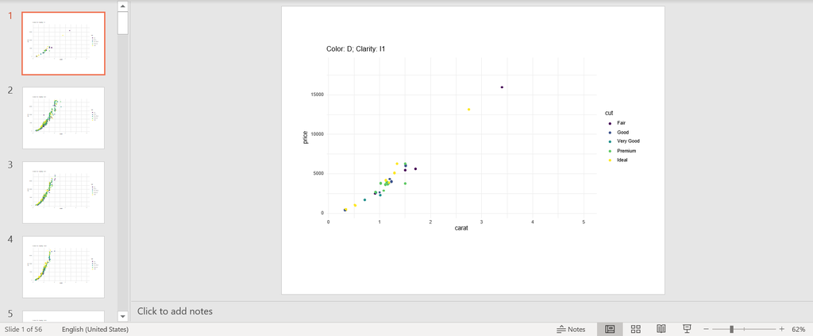

# Who should do the editing?

Now that you have editable Power Point slides, you have two parties capable of editing the graphics: (1) the R developer, and (2) the collaborator.

The R developer should do further slide editing when:

- edits are universal (i.e., reduce size of all plots to 6in x 3in).
- edits are data driven (i.e., represent all points where `carat` exceeds a value of 3 as a star)

The collaborator should do further slide editing when:

- edits are bespoke (i.e. Bob wants to see slide 25 in bold for the marketing team)
- edits are beyond the development budget (i.e., super custom axis adornment)

# Limitations

While the graphics exported to Power Point from R are editable, they do have limitations compared to graphics created within Power Point.

1. As previously mentioned, there is no linked data table behind the graphics, which can be unnerving for a colleague who wants to quality check the figure (I often export labeled and unlabeled versions of figures for this).
2. The points are not naturally grouped features as they would be for graphics created within Power Point. This means that if your colleagues wants to change the shade of yellow for the ideal cut diamonds they would have to click on *each and every single yellow point in all slides* (see Gif 3 for preview of what the slide looks like when you click around).

# Summary

Editable Power Point ggplot graphics created through `officer` + `rvg` + `purrr` can be a great way to provide your colleague with fantastic graphics while still allowing them to refine the graphics with their own finishing touches. Do expect a lot of iteration on the graphic to get it as close as possible to their needs before you hit that final send on the Power Point deck.

# Appendix

### Gif 1

Demonstration of editable features in graphic created within Power Point.

[figure not shown]

### Gif 2

Demonstration of editable data table behind graphic created within Power Point.

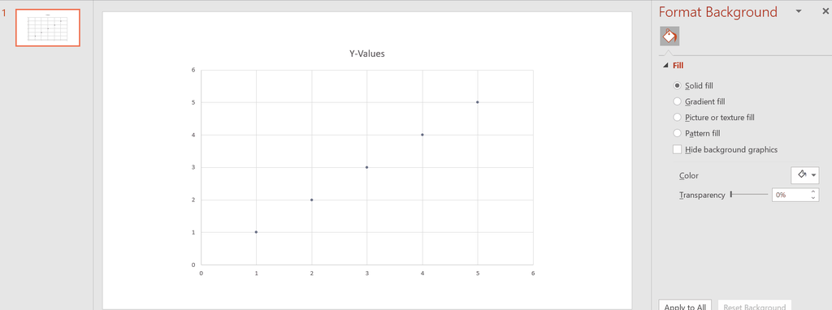

### Gif 3

Demonstration of editing title and single point color in graphic exported to Power Point by `rvg` + `officer`.

[figure not shown]

# Acknowledgments

The `create_pptx` function was modified from [Bruno Rodrigues](https://www.brodrigues.co/blog/2018-10-05-ggplot2_purrr_officer/). My colleague [Tom Nowlan](https://www.linkedin.com/in/thomas-nowlan-mph-72398011a/) figured out the function updates for `officer::ph_with` (formerly `officer::ph_with_vg`) to export figures to a specific size and location. Thumbnail artwork was adapted from [`@allison_horst`](https://twitter.com/allison_horst?lang=en).